# Exploratory Analysis

## Plastic Pollution

### Authors

Elianna Baganov, Catherine Liu, Mia Pekez, Zoe Steers

### February 20th, Winter 2023

### Abstract

In this project, we are exploring the amount of plastic pollution that occurs throughout the world. This topic is important because plastic is a widely used material, but if not properly disposed of, it has extremely negative effects on the environment.

### Keywords

Plastic, pollution, polyethylene, PVC, polyester

### Introduction

Our project aims to explore the amount of plastic pollution that occurs in the world. Using data from reports of plastic cleanups, we ask the questions: “Which countries have the most plastic pollution? Which companies are to blame for the majority of plastic pollution? What type of plastic is the most common pollutant?” These questions are important because identifying the main culprits of plastic pollution can help us get one step closer to solving the problem. Plastic pollution negatively affects organisms and ecosystems all over the world, and something needs to be done about it.

### The Topic

The topic we chose to focus on is plastic pollution. It is a topic that people are paying more attention to in the past years due to the rising awareness of environmental protection. Most plastics are not made to be recycled and take a lot of space to put in landfills. Therefore, there are many organizations and projects around the world that are making progress toward reducing plastic pollution from multiple perspectives.For example, [The Ocean Cleanup Project](https://theoceancleanup.com/) aims to tackle the problem by cleaning up existing plastics in the ocean and stopping new plastic waste from flowing from the rivers. They are a team that puts work into cutting down the number of existing plastic wastes. The [Flip the Script on Plastics](https://www.plasticpollutioncoalition.org/flipthescript), on the other hand, focuses on spreading ideas and awareness of plastic pollution prevention via media including television shows and movies. They are “building a coalition of actors, writers, directors, producers, content creators, and more in the entertainment industry committed to modeling the systemic change needed to solve the plastic pollution crisis, both on- and off-screen.” Another team called [Precious Plastic](https://preciousplastic.com/) works on recycling plastics. They suggest recycling and reusing plastics for products such as sheets. These projects and organizations proved again that plastic pollution is a concerning topic and there are many approaches to deal with it. We are interested in where the pollutants came from and what types of plastics were the source of pollution. From there we hope to work out some valuable analyses to help dealing with plastic pollution.

### The Dataset

We found this data in the [TidyTuesday data repository on GitHub](https://github.com/rfordatascience/tidytuesday/blob/master/data/2021/2021-01-26/readme.md) The data was collected by the #BreakFreeFromPlastic movement. The organizations within #BreakFreeFromPlastic complete brand audits where they report the number of plastics collected from each brand during their cleanups. The audits that correctly included the country where the plastic was collected were included in the data table, while those that did not include the country were not included in the data table, but were in the aggregate data presented in the global results on the Brand Audit report. This data was collected to determine which brand is to blame for the highest level of plastic pollution. #BreakFreeFromPlastic’s mission is to create a world free of plastic pollution, and identifying the largest culprits of plastic pollution could be the first step in achieving this. The data includes 13380 observations (rows) and 14 features (columns). One potential question of power that is implicit within this data is the availability of plastic in different countries and the systems in place to dispose of that plastic appropriately. In developed countries, there is an increasing amount of plastic-free packaging and a push for a waste-free environment. Moreover, there are extensive systems of waste management and recycling, thus facilitating a decrease in plastic pollution. However, in developing countries, plastic packaging is cheaper and thus more available. Moreover, it is less likely that well-organized waste management systems exist, thus making it more probable that plastic will end up in the environment. Therefore, when analyzing data from particular countries, it is important to question whether good plastic disposal practices are widely available and used.  
Moreover, the companies that were discerned as the highest plastic polluters in the world are also likely the largest plastic-producing companies in the world. Since they produce more products, it would make sense that their products would show up in plastic cleanups the most. However, what is not accounted for is the proportion of total company plastic production that ends up polluting the environment. Maybe some companies have higher proportions of total plastic products that end up in the environment, which would also be an area of concern when judging that particular company. Overall, while this data provides crucial insights into the amount and type of plastic pollution that happens in the world and its main culprits, it is in no way absolutely comprehensive and indicative of the actual plastic pollution occurring every year.

### Implications

Answering our research questions can have several implications for technologists, designers, and policymakers. For technologists, the data on the amount of plastic collected can be used to inform the development of new technologies and products that reduce the amount of plastic waste generated. For example, if the data shows that a particular type of plastic is collected the most, then technologists can focus their efforts on developing alternatives for that type of plastic. For designers, the data on plastic collection can inform the design of products that are more sustainable and have a less environmental impact. For example, suppose data shows that a particular company is responsible for the most amount of plastic. In that case, designers can work to design alternatives that reduce the use of plastic by that company. For policymakers, the data on plastic collection can be used to inform regulations and policies aimed at reducing plastic waste. For example, if the data shows that a particular country has the highest amount of plastic collected, policymakers can consider implementing policies that encourage companies and individuals in that country to reduce their plastic use. Additionally, the data on plastic collection in 2019 and 2020 can be used to track progress in reducing plastic waste over time and to assess the effectiveness of existing policies and initiatives aimed at reducing plastic waste.

### Limitations & Challenges

Although the creator did a good job of cleaning and categorizing the data, there are still some challenges associated with our project. The biggest challenge is understanding the differences between the materials she counted in the data. A lot of the columns hold the count of different types of plastics, which we don’t have much knowledge about at the moment. We will have to research the materials and learn their characteristics to understand the data better. There are also some limitations to our project. Since the dataset only contains data from 2019 and 2020 we could not figure out the changes in data by many years. Another limitation of this data is that it is very likely that not all plastic pollution for the given year is recorded. Since the data come from individual plastic cleanups by separate organizations that are part of #BreakFreeFromPlastic and submitted an audit, it is unreasonable to conclude that this includes all plastic. There might have been other cleanups not associated with #BreakFreeFromPlastic, cleanups that were simply not audited, or areas where plastic was not cleaned up. Thus, this dataset only shows a fraction of actual plastic pollution in the world.

### Chart 1

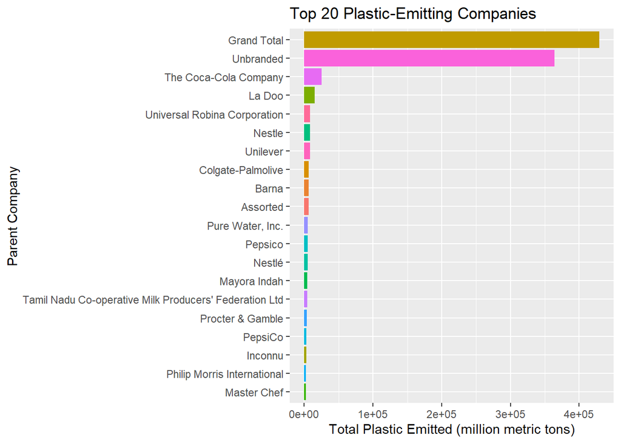

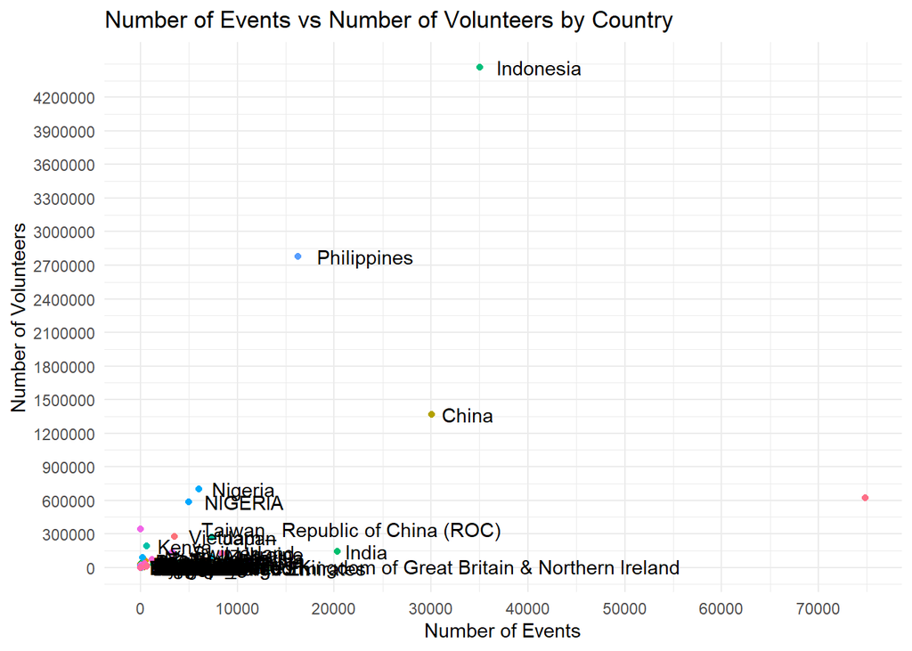

Chart 2 depicts the participation of different counties in volunteer work to collect the plastics. It includes the number of events and the number of volunteers which illustrates each country’s participation in environmental restoration.

### Chart 3

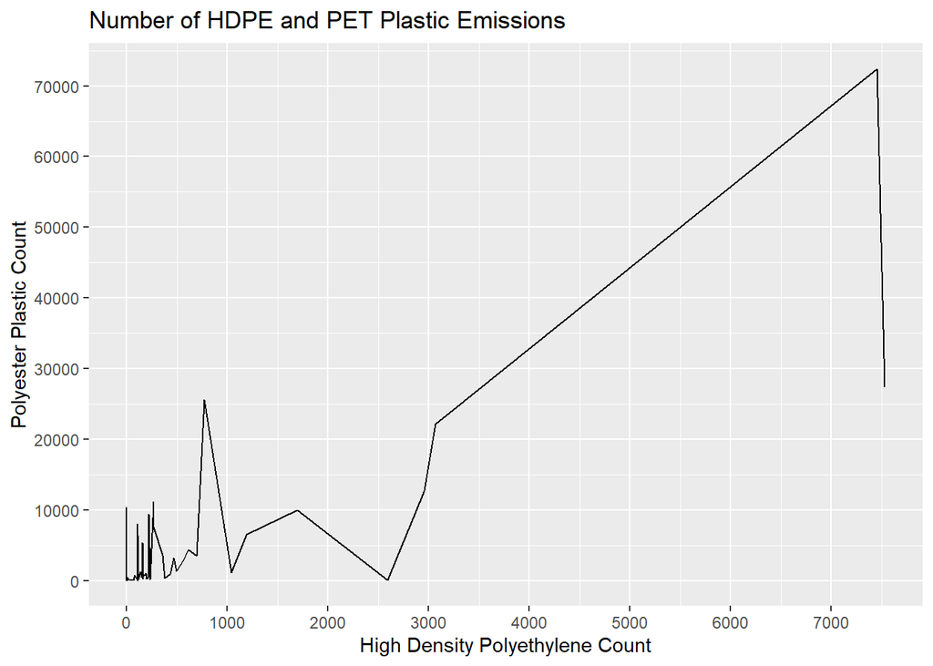

Chart 3 illustrates the relationship between the number of HDPE and PET plastic emissions. These plastics are incredibly harmful to the environment and creating a graphic like this can help bring awareness to the issue.